# Session 2 — Splines

Piecewise-linear terms · natural cubic splines · degrees of freedom · prediction plots · splines in logistic models · Lab 2

Community Medicine Workshop

## Where we are

- Session 1: found curvature; simple fixes
- Today: **splines**, the flexible, general tool
- By the end you can:
  - fit a **hinge** (piecewise-linear) term
  - fit a **natural spline** with `ns()` and choose its **df**
  - draw a **prediction plot** with a CI band
  - test **non-linearity** in a logistic model

# Topic 1 — Piecewise linear

## A hinge at age 45

```r
m_h <- lm(sbp ~ age + pmax(age - 45, 0) + bmi + salt + activity + sex + smoker, data = ncd)
round(coef(m_h)[2:3], 3)
```

```
              age pmax(age - 45, 0)
            0.272             0.288
```

```r
c(before = coef(m_h)[["age"]], after = coef(m_h)[["age"]] + coef(m_h)[[3]]) |> round(2)
```

```
before  after
  0.27   0.56
```

`pmax(age - 45, 0)` is **0 below 45** and **age − 45 above it**: its coefficient is the **change in slope**. SBP rises **0.27 mmHg per year before 45** and **0.56 after**: twice as fast. Easy to **explain**, and the slopes are **directly reportable**.

## Where is the knot?

```r
aic_k <- sapply(30:60, function(k) AIC(lm(sbp ~ age + pmax(age - k, 0) + bmi + salt + activity + sex + smoker, data = ncd)))
(30:60)[which.min(aic_k)]
```

```
[1] 45
```

The data choose **45**. But a knot **picked from the data** is not free: the search is **not counted**, so CIs are **too narrow**. Prefer a knot from **subject knowledge** (e.g. a clinical cut-off), or use a **smooth** spline.

# Topic 2 — Natural splines

## ns(): a smooth curve

```r
m_l <- lm(sbp ~ age + bmi + salt + activity + sex + smoker, data = ncd)
m_ns <- lm(sbp ~ ns(age, df = 4) + bmi + salt + activity + sex + smoker, data = ncd)
anova(m_l, m_ns)
```

```
Analysis of Variance Table

Model 1: sbp ~ age + bmi + salt + activity + sex + smoker
Model 2: sbp ~ ns(age, df = 4) + bmi + salt + activity + sex + smoker
  Res.Df    RSS Df Sum of Sq      F    Pr(>F)
1   3993 511350
2   3990 506177  3    5173.2 13.593 8.043e-09 ***
---
Signif. codes:  0 '***' 0.001 '**' 0.01 '*' 0.05 '.' 0.1 ' ' 1
```

- `ns(age, df = 4)` builds **4 columns** (a **basis**); knots go at **quantiles** of age
- **Natural** = **linear beyond the outer knots**, so the tails behave
- The 4 coefficients are **not interpretable one by one**: interpret the **curve** and **tests**
- The F test against the straight line: p ≈ 8×10⁻⁹

## How many degrees of freedom?

```r
aic_df <- sapply(1:8, function(k) AIC(lm(sbp ~ ns(age, df = k) + bmi + salt + activity + sex + smoker, data = ncd)))
round(setNames(aic_df, paste0("df", 1:8)), 0)
```

```
  df1   df2   df3   df4   df5   df6   df7   df8
30771 30735 30736 30736 30735 30735 30736 30737
```

**df = 1 is a straight line.** AIC drops by **36** at df = 2, then stays **flat**: **3 to 5 df** are plenty for age. More df just adds **wiggles** (Session 5 shows it **hurts prediction**). Rule of thumb: **3 to 5 df** for a main predictor, fewer for small data.

## A prediction plot

```r
grid <- data.frame(age = 18:80, bmi = mean(ncd$bmi), salt = mean(ncd$salt), activity = mean(ncd$activity), sex = factor("Male", levels = levels(ncd$sex)), smoker = 0)
pr <- predict(m_ns, newdata = grid, se.fit = TRUE)
grid |> mutate(fit = pr$fit, lo = fit - 1.96 * pr$se.fit, hi = fit + 1.96 * pr$se.fit) |>
  ggplot(aes(age, fit)) + geom_ribbon(aes(ymin = lo, ymax = hi), alpha = 0.25, fill = col_blue) + geom_line(linewidth = 1.2, colour = col_blue) + labs(x = "Age (years)", y = "Predicted SBP (mmHg)")
```

**Predicted SBP with a 95% band**, other variables held at **typical values** (mean BMI, salt, activity; man; non-smoker). The **plot is the result**: report it instead of the coefficients.

## A prediction plot

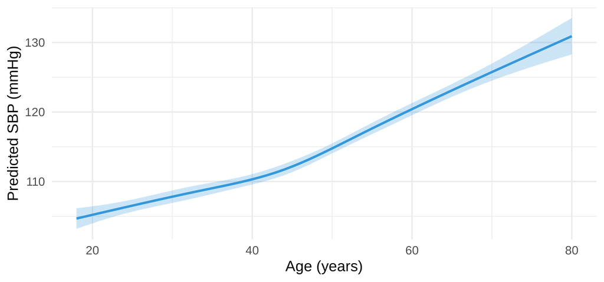

# Topic 3 — Splines for binary outcomes

## BMI and CVD risk

```r
g_ns <- glm(cvd10 ~ age + ns(bmi, 4) + sex + smoker, data = ncd, family = binomial)
g_l <- glm(cvd10 ~ age + bmi + sex + smoker, data = ncd, family = binomial)
anova(g_l, g_ns, test = "Chisq")
```

```
Analysis of Deviance Table

Model 1: cvd10 ~ age + bmi + sex + smoker
Model 2: cvd10 ~ age + ns(bmi, 4) + sex + smoker
  Resid. Df Resid. Dev Df Deviance  Pr(>Chi)
1      3995     2271.9
2      3992     2037.0  3   234.92 < 2.2e-16 ***
---
Signif. codes:  0 '***' 0.001 '**' 0.01 '*' 0.05 '.' 0.1 ' ' 1
```

```r
gb <- data.frame(bmi = seq(15, 40, 0.5), age = 50, sex = factor("Male", levels = levels(ncd$sex)), smoker = 0)
gb$p <- predict(g_ns, newdata = gb, type = "response")
ggplot(gb, aes(bmi, p)) + geom_line(linewidth = 1.2, colour = col_red) + scale_y_continuous(labels = scales::percent) + labs(x = "BMI", y = "10-year CVD risk")
```

Likelihood-ratio test: deviance drop **235 on 3 df**, so a straight line is **not enough**. The curve is **U-shaped**: lowest near **BMI 24 to 25**, high for low BMI, much higher for **obesity**.

## BMI and CVD risk

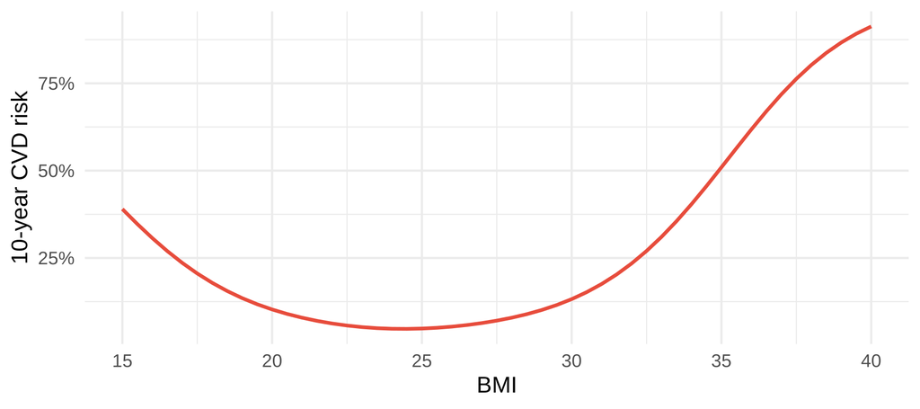

## Cautions

- Predictions **outside the data range** are **extrapolation** (the natural spline continues in a straight line)
- A spline with **too many df** fits **noise** (Session 5)
- Put the spline **inside the model** with the other predictors, then predict **holding them fixed**

## 🔧 Switch to R — Lab 2

**File:** `curves-workshop/labs/lab2_splines.R`

- hinge term, slopes and knot search
- natural spline, df choice, prediction plot
- spline for BMI in a logistic model

**Time:** 40 minutes · answer the Q questions in the comments

## Self-check quiz (1/5)

In a model with age + pmax(age - 45, 0), the coefficient of the hinge term is 0.29. What does it estimate?

- The mean SBP of the adults who are older than 45 years in the survey
- The slope of SBP in the adults who are older than 45 years of age
- The age at which SBP starts to rise among the adults in the survey
- The change in slope after age 45 compared with the slope before

## Self-check quiz (2/5)

Why is picking the knot from the data (the best AIC over many knots) a problem?

- The search is not counted, so the CIs come out too narrow
- The model can no longer be fitted by least squares once the search is done
- Knots chosen from the data bias the estimates of every other coefficient
- The AIC cannot be computed for a model whose knot was found by searching

## Self-check quiz (3/5)

What is the best description of ns(age, df = 4)?

- Four straight segments joined at the quartiles of age in the survey data
- A smooth curve whose four basis coefficients are not read one by one
- A polynomial of degree four in age, in which each coefficient has a clear meaning
- Four separate age effects, one for each of four fixed age groups in the data

## Self-check quiz (4/5)

The AIC for natural splines with 1 to 8 df is 30,771 then about 30,735 from 2 df onwards. Which choice is sensible?

- 8, since more flexibility gives a more correct curve for the data
- 1, since a straight line is preferred to a curve whatever the AIC
- No value can be justified, because AIC cannot help to choose the df
- A small number such as 3 or 4, since more flexibility adds nothing

## Self-check quiz (5/5)

How is a prediction plot with a 95% band for a spline model built?

- Predict over a grid of ages with se.fit, with the other variables fixed
- Plot the fitted values of the sample against age and join the points together
- Plot each spline coefficient against the age at which its knot is placed
- Fit a separate model for each age in the data and plot the intercepts

## Score and take-home

**Your score:**

- **Hinge** `pmax(x - k, 0)`: change in slope at a chosen knot
- **`ns(x, df)`**: smooth natural spline, 3 to 5 df
- Test non-linearity with **anova** (F or LR test)
- **Prediction plot with a CI band** is the result
- Beware **extrapolation** and too many df

**Next:** Session 3: generalised additive models